# Introduction

The NY Metropolitan Transport Authority provides detailed data files on transit usage to the public to encourage developers to build application and tools to help MTA riders. For this project we are looking at a dataset that combines MTA subway turnstile usage with weather reports from wunderground.com to determine if more people ride the subway when it is raining versus when it is not raining.

# Statistical Test

The statistical hypothesis we will test is shown below.

$H_0$ : the population mean for rider traffic is the same for both rain and dry conditions

$H_a$ : the population mean for rider traffic is greater for rain conditions vs dry conditions.

Before we get to that we need to examine the quality of data and possibly make some transformations to remove any obvious inconsistencies that might skew our test result.

For the discussion in this [IPython Notebook](http://ipython.org/notebook.html) we'll import in a number of Python libraries. Most were used throughout the Intro to Data Science course, but I've added a few that add some convenience functions for regression and visualization.

**patsy**

- creates a model design from a text formula describing the relationship between explanatory and response variables. Statsmodels has variants of regression models that allow for use of pasty formulas.

**[seaborn](http://stanford.edu/~mwaskom/software/seaborn/index.html)**

- is a visualization library built on matplotlib. It provides improvements to existing plotting functions and adds a number of plot types that we'll use below.

```python
%matplotlib inline
```

```python
import numpy as np
from numpy.random import randn
import pandas as pd
from scipy import stats
import statsmodels.api as sm
import statsmodels.formula.api as smf
import matplotlib as mpl
import matplotlib.pyplot as plt
import seaborn as sns
import patsy
import datetime
```

```python
sns.set_palette("deep", desat=.6)
sns.set_context(rc={"figure.figsize": (8, 4)})
```

The original class dataset is loaded from a CSV file into a [pandas](http://pandas.pydata.org/) DataFrame.

```python
df = pd.read_csv(r'C:\Users\JB9814\Documents\Training\DataAnalyst\turnstile_data_master_with_weather.csv')
# remove unnamed indexing column that was imported from the csv file
df=df.ix[:,1:]
```

Examining the data in excel we see:

- the rain attribute indicates whether a day had rain or not and it applies to all UNITs in the dataset. It doesn't vary by either UNIT or time of day.
- The TIMEn attribute shows the interval over which ENTRIESn_hourly is accumulated varies widely - from minutes to four hours. Looking at the distribution of the entry counts would be misleading since they arent over a constant interval.

To get a useful entry count we'll roll up the data set by DATEn to get daily entry values at each UNIT for our rain / no rain test.

```python
df_entries = df[['UNIT','DATEn','ENTRIESn_hourly','rain']].groupby(['UNIT','DATEn','rain'],as_index=False).sum()
df_entries.rename(columns={'ENTRIESn_hourly':'ENTRIESn_daily'},inplace=True)
```

```python
# Add some useful columns for day of week and weekday vs weekend
df_day_week = df_entries['DATEn'].map(lambda x: datetime.datetime.strptime(x,"%Y-%m-%d").weekday())
df_weekday = df_day_week < 5
df_entries = df_entries.assign(day_week=df_day_week)
df_entries = df_entries.assign(weekday=df_weekday)
```

```python
entries_rain = df_entries[(df_entries.rain == 1)]['ENTRIESn_daily']
entries_norain = df_entries[(df_entries.rain != 1)]['ENTRIESn_daily']
```

Now lets compare the distributions visually using a normalized histogram. The rain and norain groups have different number of entries, so by normalizing the frequency counts and overlaying the histograms the two shapes can be compared.

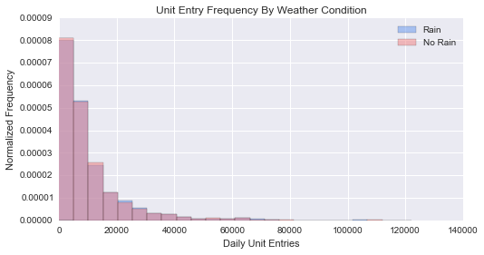

```python
# create an overlayed histogram to compare the two distributions of entries
bins = np.linspace(0, np.r_[entries_rain, entries_norain].max(), 25)
plt.hist(entries_rain.values, bins, normed=True, color="#6495ED", alpha=.5, label="Rain")
plt.hist(entries_norain.values, bins, normed=True, color="#F08080", alpha=.5, label="No Rain");
plt.legend()
plt.title("Unit Entry Frequency By Weather Condition")
plt.xlabel("Daily Unit Entries")
plt.ylabel("Normalized Frequency")
```

The two histograms appear similar and non-normal. Since sample n is large we'll use the t-test as the statistical test for the hypothesis.

```python
(entries_rain.mean(),entries_norain.mean(),stats.ttest_ind(entries_rain,entries_norain,equal_var=False))
```

```
(10502.931279620852,
 10332.008629989212,
 (0.78863449982330003, 0.43034602531693533))
```

The means for the rain and no rain groups were 10502 and 10332 respectively.

In the independent samples t-test for the rain and norain showed the distributions were not determined to be significantly different (Welch's T-Test t=.789, p = .215 > p-critical 0.05, one-sided). We cannot reject $H_0$.

*stats.ttest_ind returns two-sided result

Below is another visualization of the data catagorized by day of week.

The seaborn factorplot can be used to display the mean and 95% confidence interval of a dependent variable based on independent categorical variables. The example below shows the mean daily entries at each unit for each day of the week and the weather.

Except for day 0 (Mon), the means are similar.

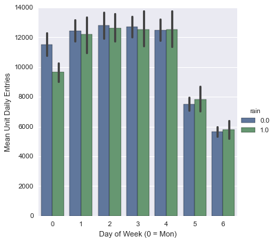

```python
sns.factorplot( "day_week", "ENTRIESn_daily", "rain", df_entries, kind="auto", estimator=np.mean)
sns.axlabel("Day of Week (0 = Mon)", "Mean Unit Daily Entries")
```

Now we'll repeat the result with an improved dataset that provides more granular indications of weather by a categorical attribute named 'conds'. Weather conditions are provided every 4 hours and can vary by UNIT.

```python
df = pd.read_csv(r'C:\Users\JB9814\Documents\Training\DataAnalyst\improved-dataset\turnstile_weather_v2.csv')
```

```python
#
# Data is collected over 4 hour intervals, except in many instances, the 08:00:00 value is missing.
# The 12:00:00 ENTRIESn_hourly value is over an 8 hour interval in that case.
#
df[['TIMEn','UNIT']].groupby(['TIMEn'],as_index=False).size()
```

```
TIMEn
00:00:00    7378
04:00:00    7381
08:00:00    5914
12:00:00    7335
16:00:00    7298
20:00:00    7343
dtype: int64
```

To clean up the dataset so the comparisons will be between uniform collection intervals, we'll remove any collection records that are not over a 4 hour interval.

```python
collection_interval = (df.hour-df.hour.shift(1)).fillna(4)
df = df.assign(coll_int = collection_interval)
# hour difference is -20 on day roll over.
df = df[df['coll_int'].isin([-20,4])]
```

For this analysis, we'll create a new attribute, rain1, which will be True if 'conds' is either Light Rain or Heavy Rain.

```python
df[['conds','UNIT']].groupby(['conds'], as_index=False).size()
```

```
conds
Clear               13248
Fog                    47
Haze                 1273
Heavy Rain            287
Light Drizzle         301
Light Rain           1770
Mist                   24
Mostly Cloudy        6105
Overcast            11521
Partly Cloudy        2141
Rain                  954
Scattered Clouds     3307
dtype: int64
```

```python
df_coi_rain1 = df.assign(rain1 = lambda x: x['conds'].isin(['Light Rain','Heavy Rain']))

df_rain1=df_coi_rain1[df_coi_rain1.rain1 == True]
df_norain1=df_coi_rain1[df_coi_rain1.rain1 == False]
```

```python
data1 = df_rain1['ENTRIESn_hourly'].values
data2 = df_norain1['ENTRIESn_hourly'].values
max_data = np.r_[data1, data2].max()
bins = np.linspace(0, max_data, 25)
```

Now lets compare the distributions again using a normalized histogram. The rain and norain groups now show differences in skew.

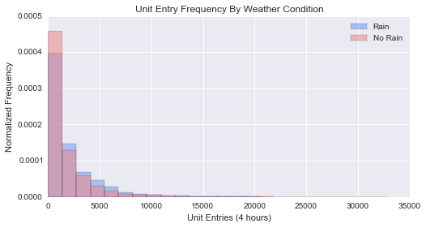

```python
plt.hist(data1, bins, normed=True, color="#6495ED", alpha=.5, label="Rain")
plt.hist(data2, bins, normed=True, color="#F08080", alpha=.5, label="No Rain");
plt.legend()
plt.title("Unit Entry Frequency By Weather Condition")
plt.xlabel("Unit Entries (4 hours)")
plt.ylabel("Normalized Frequency")
```

The seaborn distplot function produces a figure that includes both a normalized histogram and a kernal density estimate of the probabity density function. The KDE gives us another plot for visual comparison.

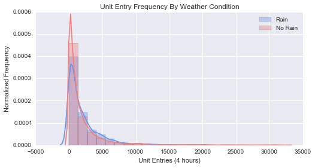

```python
sns.distplot(data1, bins, color="#6495ED", label="Rain")
sns.distplot(data2, bins, color="#F08080", label="No Rain");
plt.legend()
plt.title("Unit Entry Frequency By Weather Condition")
plt.xlabel("Unit Entries (4 hours)")
plt.ylabel("Normalized Frequency")
```

Since these are large unequal sized samples & we're making no assumptions about equal variance in the populations, we can also use a one-sided Welch's t-test to test the hypothesis.

```python
(df_rain1['ENTRIESn_hourly'].mean(),df_norain1['ENTRIESn_hourly'].mean(),
 stats.ttest_ind(df_rain1['ENTRIESn_hourly'],df_norain1['ENTRIESn_hourly'],equal_var=False))
```

```
(2161.4491978609626,
 1871.0163150998176,
 (4.3844257784758947, 1.215508698975088e-05))
```

The means for the rain and no rain groups were 2161 and 1871 respectively. In the independent samples t-test for the rain and norain showed the distributions were significantly different (Welch's T-Test t=4.38, p = 6.1e-6 < p-critical 0.05, one-sided). We can reject $H_0$. Larger entry volume appears to be correlated with rainy conditions.

*stats.ttest_ind returns two-sided result

# Linear Regression

Now let's see if we can define a reasonable predictive model for rider entries using the attributes in the improved dataset.

To do that we'll use patsy to define design matrices using R-like formulas. By intuition, volume should depend on time of day, day of week, weather conditions and location. That model is tested below using statsmodels ordinary least squares (OLS) regression.

One advantage of the pasty formula is it automatically creates dummy variables from categorical data & removes one of the values to avoid multicollinearity (where predictor variables are correlated).

In the results summary of this model, the coefficient of determination, $R^2$ is 0.548. 54.8% of the variance of ENTRIESn_hourly can be explained by the attributes we chose in the model.

All predictors in this model are categorical and weather conditions turns out to not be that significant in the model. If 'conds' is removed from the formula, $R^2$ drops to 0.546. Intuitively this makes sense - the factors associated people going to and from work (day of week & time of day) overwhelms the weather factor.

```python
f='ENTRIESn_hourly ~ UNIT + TIMEn + C(day_week) + conds'
y, X = patsy.dmatrices(f, df_coi_rain1,
                       return_type='dataframe')
```

```python
    model = sm.OLS(y,X)
    results  = model.fit()
    print (results.summary())
```

```
                            OLS Regression Results
==============================================================================
Dep. Variable:        ENTRIESn_hourly   R-squared:                       0.548
Model:                            OLS   Adj. R-squared:                  0.545
Method:                 Least Squares   F-statistic:                     189.1
Date:                Mon, 06 Apr 2015   Prob (F-statistic):               0.00
Time:                        12:58:36   Log-Likelihood:            -3.6984e+05
No. Observations:               40978   AIC:                         7.402e+05
Df Residuals:                   40716   BIC:                         7.425e+05
Df Model:                         261
Covariance Type:            nonrobust
=============================================================================================
                                coef    std err          t      P>|t|      [95.0% Conf. Int.]
---------------------------------------------------------------------------------------------
Intercept                  -171.8031    168.941     -1.017      0.309      -502.932   159.326
UNIT[T.R004]                338.5117    227.602      1.487      0.137      -107.593   784.616
UNIT[T.R005]                289.9373    229.320      1.264      0.206      -159.536   739.410
UNIT[T.R006]                456.1305    223.588      2.040      0.041        17.894   894.367
UNIT[T.R007]                138.6535    231.125      0.600      0.549      -314.357   591.664
UNIT[T.R008]                164.5179    231.867      0.710      0.478      -289.946   618.982
UNIT[T.R009]                156.9958    227.269      0.691      0.490      -288.457   602.449
UNIT[T.R011]               7135.8047    222.427     32.082      0.000      6699.843  7571.766
UNIT[T.R012]               8479.9955    221.347     38.311      0.000      8046.151  8913.840
UNIT[T.R013]               2378.4363    221.347     10.745      0.000      1944.592  2812.280
UNIT[T.R016]                564.7324    222.414      2.539      0.011       128.797  1000.668
UNIT[T.R017]               3993.4309    221.347     18.042      0.000      3559.587  4427.275
UNIT[T.R018]               7604.9706    221.538     34.328      0.000      7170.750  8039.191
UNIT[T.R019]               3115.4289    221.080     14.092      0.000      2682.106  3548.751
UNIT[T.R020]               6169.5277    221.347     27.873      0.000      5735.684  6603.372
UNIT[T.R021]               4525.7491    222.428     20.347      0.000      4089.785  4961.714
UNIT[T.R022]               9313.9202    221.347     42.078      0.000      8880.076  9747.764
UNIT[T.R023]               5949.0976    221.347     26.877      0.000      5515.254  6382.942
UNIT[T.R024]               3043.2935    221.614     13.732      0.000      2608.924  3477.663
UNIT[T.R025]               5212.3214    221.080     23.577      0.000      4778.999  5645.644
UNIT[T.R027]               2763.5331    221.347     12.485      0.000      2329.689  3197.377
UNIT[T.R029]               7025.5062    221.347     31.740      0.000      6591.662  7459.350
UNIT[T.R030]               2895.6998    221.347     13.082      0.000      2461.856  3329.544
UNIT[T.R031]               4147.4686    221.347     18.737      0.000      3713.625  4581.313
UNIT[T.R032]               4243.5712    221.875     19.126      0.000      3808.691  4678.451
UNIT[T.R033]               8030.4793    221.347     36.280      0.000      7596.635  8464.323
```

[output cut: 230 more lines]

```
conds[T.Mist]              1461.1246    414.962      3.521      0.000       647.790  2274.459
conds[T.Mostly Cloudy]     -301.7972     35.011     -8.620      0.000      -370.420  -233.174
conds[T.Overcast]           -38.5394     27.423     -1.405      0.160       -92.289    15.210
conds[T.Partly Cloudy]      -44.3093     49.214     -0.900      0.368      -140.770    52.151
conds[T.Rain]               -66.4070     69.319     -0.958      0.338      -202.275    69.461
conds[T.Scattered Clouds]    -9.5295     43.512     -0.219      0.827       -94.815    75.756
==============================================================================
Omnibus:                    28983.867   Durbin-Watson:                   1.507
Prob(Omnibus):                  0.000   Jarque-Bera (JB):          1046312.527
Skew:                           2.971   Prob(JB):                         0.00
Kurtosis:                      27.031   Cond. No.                         301.
==============================================================================

Warnings:
[1] Standard Errors assume that the covariance matrix of the errors is correctly specified.
```

# Conclusion

In this study we examined two datasets of MTA turnstile traffic. In the first dataset, two groups of entry traffic were separated into rain and norain days. At that level of granularity, the null hypothesis that the mean daily entries were the same could not be rejected.

The improved dataset provided more accurate weather conditions and allowed for comparison of entry values that were collected over the same interval. That dataset showed that higher entry values can be correlated with rainy weather.

The linear regression model showed that the dominant predictors for traffic was time of day and day of week. Weather was not nearly as significant in the model.

# Reflection

When examining the original data set, I originally rolled up all entry totals to daily values, since the rain attribute was the same for all units and time of day. This resulted in a RAIN sample size of 10 and an NO RAIN sample size of 20. Both distributions were not normal and were relatively small - I didn't feel I could use either the Mann-Whitney or T-Test due to the size. To get a larger sample number I used Daily Unit entries instead. This is an area for future learning - what kind of transformations can be done on data sets and how do they impact tests and conclusions?

Mann-Whitney U test did not work properly on my windows machine. I originally tried to use it to compare distributions since it is more efficient for non-normal datasets, but the function returned 'nan' for the p value. Another area for learning is selecting the best test for various sample sizes.

For the improved dataset, my solution for getting comparable entry values was to omit data that did not rollup entry counts over 4 hours. I thought about converting values to true hourly rate, but I still would not be able to reconstruct the missing 'conds' value - so I felt it was better to just omit the data to remove any skew that it could cause.

Visualization is another area for future exploration as well. I used seaborn's boxplot and violin plots to compare the rain and norain groups. Since the data is highly positively skewed the upper whisker was quite long and it was difficult to compare the quartiles. I could have tried to use a log of the values to make the comparison easier. Seaborn also has many plots for models that use categorical data. I really just scratched the surface in this exercise.

# References

"Python" Python.org. Python Software Foundation, n.d. Web. 06 Apr. 2015.  
"Seaborn: statistical data visualization", http://stanford.edu/~mwaskom/software/seaborn-dev/index.html, n.d. Web. 06 Apr. 2015.  
"Scipy.org - Stats", http://docs.scipy.org/doc/scipy/reference/stats.html, n.d. Web. 06 Apr. 2015.  
"pandas: powerful Python data analysis toolkit", http://pandas.pydata.org/pandas-docs/stable/index.html, n.d. Web. 06 Apr. 2015.  
"patsy - Describing statistical models in Python", http://patsy.readthedocs.org/en/latest/, n.d. Web. 06 Apr. 2015.  
"Statsmodels", http://statsmodels.sourceforge.net/, n.d. Web. 06 Apr. 2015.  
"Ipython - Interactive Computing", http://ipython.org/notebook.html, n.d. Web. 06 Apr. 2015  
"Student's t-test", http://en.wikipedia.org/wiki/Student%27s_t-test, n.d. Web. 06 Apr. 2015  
"Mann–Whitney U test", http://en.wikipedia.org/wiki/Mann%E2%80%93Whitney_U_test, n.d. Web. 06 Apr. 2015  
"Coefficient of determination", http://en.wikipedia.org/wiki/Coefficient_of_determination, n.d. Web. 06 Apr. 2015  
"Statistical hypothesis testing", http://en.wikipedia.org/wiki/Statistical_hypothesis_testing, n.d. Web. 06 Apr. 2015